# Initial Analysis Report

[figure not shown]

```r
tukey_anova <- aov(math1 ~ ladder1, data = anova_df)
t <-TukeyHSD(tukey_anova, conf.level = 0.95)
df <- as.data.frame(t$ladder1)
df$ladder_type <- rownames(df)
ggplot(df, aes(x = ladder_type, y = diff)) +
  geom_pointrange(aes(ymin = lwr, ymax = upr), lwd =1.5, size = 0.7, col = "deeppink4")+
   geom_hline(yintercept=0, linetype='dotted', col = 'azure4', lwd =1) +
  labs(x = "Class Size",
       y = "Difference in Mean",
       title = "95% Familiy-Wise Confidence Interval of Difference of Means Using Tukey's Range Test") +
  theme_bw() +
  theme(panel.grid.major.y = element_blank(),
        legend.position = "off") +
  theme(plot.title = element_text(size=10))
```

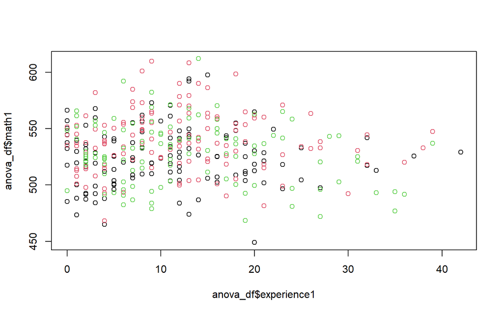

```r
plot(anova_df$math1 ~ anova_df$experience1, col = anova_df$star1)
```

The distribution of scaled math score by school ID shows that we have uneven distribution of math score.

```r
summary <- STAR %>%
                group_by(schoolid1) %>%
                summarise(mean = mean(math1, na.rm = T))

head(summary, 10) %>%
  kbl(caption = "Average Scaled Math Score By School ID (First 10)") %>%
  kable_classic(full_width = T, html_font = "Cambria")
```

Average Scaled Math Score By School ID (First 10)

| schoolid1 | mean |
| --- | --- |
| 1 | 536.8969 |
| 2 | 493.7500 |
| 3 | 558.8818 |
| 4 | 524.2714 |
| 5 | 517.1892 |
| 7 | 552.6102 |
| 8 | 526.5161 |
| 9 | 551.2000 |
| 10 | 567.8966 |
| 11 | 550.9351 |

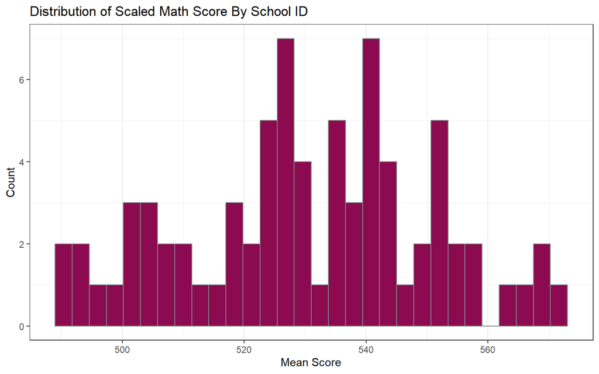

```r
ggplot(summary, aes(x = mean)) +
  geom_histogram(fill = "deeppink4", color = "azure4") +
  labs(x = "Mean Score",
       y = "Count",
       title = "Distribution of Scaled Math Score By School ID") +
  theme_bw() +
  theme(panel.grid.major.y = element_blank(),
        legend.position = "off")
```

# Inferential Analysis

### Choice of Model

The model is defined with a two way ANOVA model as follows

$$Y_{ijk} = \mu_{..} + \alpha_{i} +
\beta_{j} + \epsilon_{ijk}$$

where the index $i$ represents the class type: small ($i=1$), regular ($i=2$), regular with aide ($i=3$), and the index $j$ ($j = 1,...,76)$ represents the school indicator. The index $k$ ($k = 1,...,n_{ij}$) represents the teacher of the $i$th class type and in the $j$th school.

Note that we have far more $\beta_{j}$ than $\alpha_{i}$. Including the interaction terms $\alpha_{i} \beta_{j}$ into the model will significantly increases the complexity of the model. Since our question of interest is mostly related with $\alpha_{i}$, increasing the model complexity by introducing the interaction terms will not significantly help our analysis. Therefore, the interaction terms will not be included to the model.

*Explanation of the notation*

- $Y_{ijk}$ represents the mean math scaled score of 1st grade students of the $i$ th class type and the $j$ th school for the $k$ th teacher.
- $\mu_{..}$ represents the overall mean of math scaled scores of all students regardless of class types and school.
- $\alpha_{i}$ represents the main effect of the $i$ th class type. We have constraint that $\sum_i \alpha_{i} = 0$.
- $\beta_{j}$ represents the main effect of the $j$ th school. We have constraint that $\sum_j \beta_{j} = 0$.
- $\epsilon_{ijk}$ represents the random error in the $i$ th class type and the $j$th school for the $k$ th teacher.

*Assumptions of the Model*

We have $\{\epsilon_{ijk}\}$ are independently and identically distributed $N(0,\sigma^2)$. This implies that our response variable $Y_{ijk}$ is also normally distributed and variance across the each group is equal.

### Model Fitting

The fitted result is very lengthy because we have many factor levels for `schoolid1`. The coefficients of the model should be interpreted as follow:

1. Intercept: mean math scaled score of 1st grade students of the regular class type of the school with schoolid 1.
2. Coefficient of class type variable: change in mean math score of 1st grade students by changing the class type, assuming that every other variable stays the same.
3. Coefficient of schoolid variable: change in mean math score of 1st grade students by changing the schoolid, assuming that every other variable stays the same.

By observing these interpretation of each coefficient, we can clearly see that reporting these coefficient is not very helpful in answering our question of interest.

```r
anova_df <- STAR %>%
              select(math1, star1, schoolid1, experience1, tethnicity1) %>%
              filter(!is.na(math1) & !is.na(star1) & !is.na(schoolid1)) %>%
              group_by(star1, schoolid1, experience1, tethnicity1) %>%
              summarise(math1 = mean(math1))

y = lm(math1 ~ star1 + schoolid1, data=anova_df)
summary(y)
```

```
##
## Call:
## lm(formula = math1 ~ star1 + schoolid1, data = anova_df)
##
## Residuals:
##     Min      1Q  Median      3Q     Max
## -54.502 -10.259  -0.808   9.211  83.528
##
## Coefficients:
##                   Estimate Std. Error t value Pr(>|t|)
## (Intercept)       539.5922     9.8042  55.037  < 2e-16 ***
## star1small         14.3207     2.4856   5.762 2.14e-08 ***
## star1regular+aide   2.0704     2.6142   0.792 0.429027
## schoolid12        -50.8106    14.8865  -3.413 0.000734 ***
## schoolid13         15.1280    12.5829   1.202 0.230248
## schoolid14        -19.2433    13.7921  -1.395 0.164019
## schoolid15        -29.7689    13.7921  -2.158 0.031723 *
## schoolid17         13.9164    12.2140   1.139 0.255489
## schoolid18        -18.4298    12.5795  -1.465 0.143994
## schoolid19          2.5537    11.9362   0.214 0.830738
## schoolid110        35.8261    13.7936   2.597 0.009879 **
## schoolid111         5.4803    13.7781   0.398 0.691104
## schoolid112        -9.9892    14.8865  -0.671 0.502746
## schoolid113         9.1460    14.8865   0.614 0.539448
## schoolid114       -22.9383    13.7781  -1.665 0.097032 .
## schoolid115       -38.9336    14.8935  -2.614 0.009416 **
## schoolid116       -37.6549    12.5829  -2.993 0.003006 **
## schoolid117       -41.9897    13.7781  -3.048 0.002521 **
## schoolid119       -51.0425    12.5795  -4.058 6.39e-05 ***
## schoolid120       -14.1669    13.0752  -1.083 0.279496
## schoolid121       -42.0767    12.5795  -3.345 0.000932 ***
## schoolid122       -42.5428    11.9623  -3.556 0.000439 ***
## schoolid123        -2.2893    13.0837  -0.175 0.861224
## schoolid124        -9.7994    13.0757  -0.749 0.454208
## schoolid125       -38.6475    13.7921  -2.802 0.005421 **
## schoolid126       -60.3255    14.9105  -4.046 6.70e-05 ***
## schoolid127       -20.9081    11.7149  -1.785 0.075354 .
## schoolid128       -33.1901    12.2239  -2.715 0.007024 **
## schoolid129         1.1254    14.8865   0.076 0.939790
## schoolid130       -57.0084    13.7936  -4.133 4.70e-05 ***
```

[output cut: 39 more lines]

```
## schoolid171       -19.3643    13.7936  -1.404 0.161437
## schoolid172        23.8428    12.5829   1.895 0.059114 .
## schoolid173        22.9327    13.7936   1.663 0.097488 .
## schoolid174        27.1357    13.7936   1.967 0.050112 .
## schoolid175       -17.8876    12.5795  -1.422 0.156118
## schoolid177        10.7395    12.5829   0.853 0.394093
## schoolid178       -16.6669    14.8865  -1.120 0.263818
## schoolid179       -12.1458    13.7921  -0.881 0.379249
## schoolid180        -3.6364    14.8865  -0.244 0.807190
## ---
## Signif. codes:  0 '***' 0.001 '**' 0.01 '*' 0.05 '.' 0.1 ' ' 1
##
## Residual standard error: 19.49 on 288 degrees of freedom
## Multiple R-squared:  0.6044, Adjusted R-squared:  0.4986
## F-statistic: 5.714 on 77 and 288 DF,  p-value: < 2.2e-16
```

### F-Test

To answer the question of interest whether there is any differences in math scaled scores in 1st grade across class types, we can perform the F-test using anova using a significance level of 0.05. The hypothesis to test will be:

$$H_{0}: \alpha_{i} = 0 \\ H_{1}: {\rm not
\ all\ } \alpha_{i} {\rm \ are \ } 0$$

```r
t2 = Anova(lm(math1 ~ star1 + schoolid1, data=anova_df), type=2)
t2
```

```
## Anova Table (Type II tests)
##
## Response: math1
##           Sum Sq  Df F value    Pr(>F)
## star1      14552   2 19.1642 1.535e-08 ***
## schoolid1 151294  75  5.3132 < 2.2e-16 ***
## Residuals 109346 288
## ---
## Signif. codes:  0 '***' 0.001 '**' 0.01 '*' 0.05 '.' 0.1 ' ' 1
```

*Key Findings*

1. The bigger than F-value is, there is greater variation between the means of each group than variation within the sample. Since we have higher F-value for class type than school id, it implies that the mean of math test score across the school was more similar than the mean of math test score across the class types.
2. The P-value of the class type is far below 0.05, we can reject our null hypothesis at significance level of 0.05. This means we can conclude that we there exist a statistically significant difference in mean across the class type, answering our question of interest that there is a differences in math scaled scores in 1st grade across class types at significance level of 0.05.

### Tukey’s Range Test

We perform the Tukey’s Range Test to see which class type is associated with the highest math scaled scores in 1st grade. The plot below shows 95% Familiy-Wise Confidence Interval of Difference of Means Using Tukey’s Range Test.

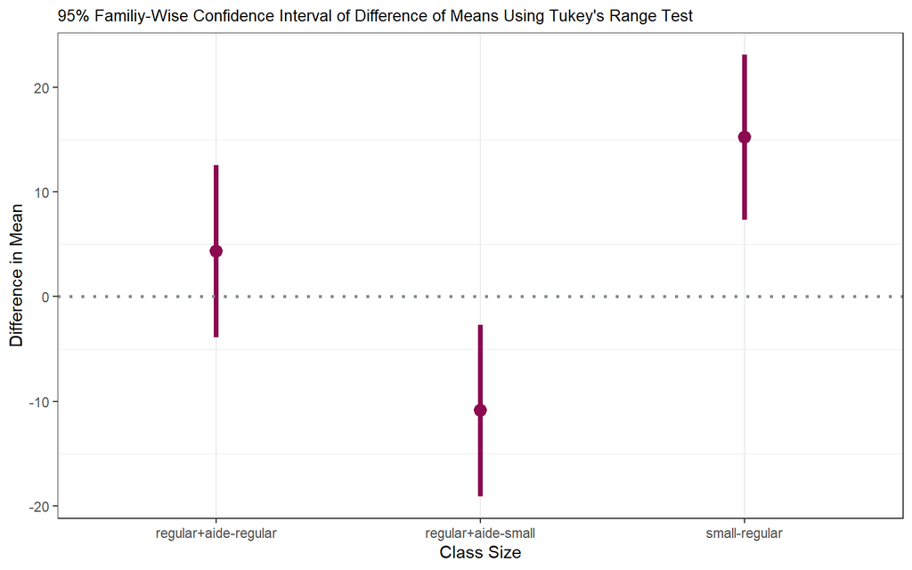

```r
tukey_anova <- aov(math1 ~ star1, data = anova_df)
t <-TukeyHSD(tukey_anova, conf.level = 0.95)
df <- as.data.frame(t$star1)
df$class_type <- rownames(df)
ggplot(df, aes(x = class_type, y = diff)) +
  geom_pointrange(aes(ymin = lwr, ymax = upr), lwd =1.5, size = 0.7, col = "deeppink4")+
   geom_hline(yintercept=0, linetype='dotted', col = 'azure4', lwd =1) +
  labs(x = "Class Size",
       y = "Difference in Mean",
       title = "95% Familiy-Wise Confidence Interval of Difference of Means Using Tukey's Range Test") +
  theme_bw() +
  theme(panel.grid.major.y = element_blank(),
        legend.position = "off") +
  theme(plot.title = element_text(size=10))
```

*Key Findings*

1. From the plot above, we can statistically conclude that there is no difference in mean between regular and regular+aide at significance level of 0.05. This implies that effect of having academic aide inside the classroom might be negligible that it does not improve student’s math test score.
2. The plot demonstrate that difference in mean between regular+aide and small is statistically negative and difference in mean between small and regular is statistically positive (both at significance level of 0.05). The such results implies that there exists a statistical evidence that small class size is more associated with the highest math scaled score in the 1st grade.

# Sensitivity Analysis

In the sensitivity analysis, we will explore whether the assumptions we made for the ANOVA model are plausible.

### Equal Variance Assumption

To see if we have an equal variance across the groups, we should observe residual vs fitted plot and check if we have even spread of points around the y = 0.

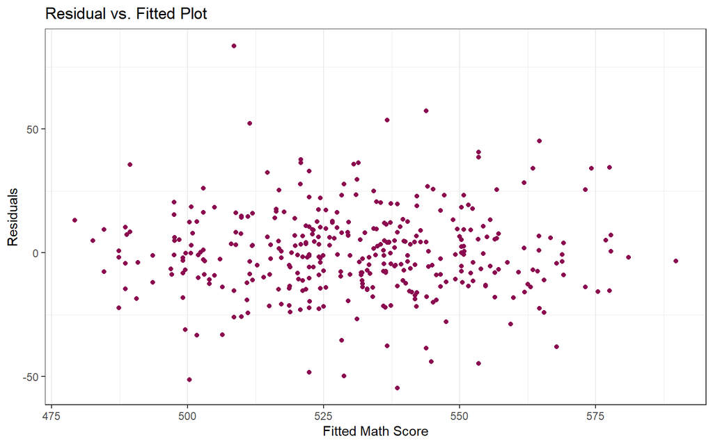

```r
ggplot(y) +
  geom_point(aes(x = .fitted, y = .resid), color = "deeppink4") +
  labs(title = "Residual vs. Fitted Plot", x = "Fitted Math Score", y = "Residuals") +
  theme_bw() +
  theme(panel.grid.major.y = element_blank(),
        legend.position = "off")
```

The plot above shows fairly even spread of points around the line y = 0, help us to make a claim that the variance across the group might be equal. We can statistically test such claim using the Levene Test.

The hypothesis of the Levene Test is:

$$H_{0}: {\rm expected \ absolute \
deviation \ across \ the \ all \ groups \ are \ equal. } \\
H_{1}: {\rm expected \ absolute \ deviation \ across \ the \ all \
groups \ are \ not \ equal. }$$

```r
#Levene Test
leveneTest(math1 ~ star1 * schoolid1, data=STAR)
```

```
## Levene's Test for Homogeneity of Variance (center = median)
##         Df F value    Pr(>F)
## group  223  2.2331 < 2.2e-16 ***
##       6376
## ---
## Signif. codes:  0 '***' 0.001 '**' 0.01 '*' 0.05 '.' 0.1 ' ' 1
```

The result of the levene test shows that we can reject the null hypothesis at the significance level of 0.05, so we have statistical evidence that the variance across the groups are not equal. The result is quiet surprising that it counters our previous claim that variance across the group will be equal. This result show that our equal variance assumption is not feasible for the given dataset.

### Normality Assumption

We assumed that error will be normally distributed, therefore our response variable will be normally distributed as well. We can check the following assumption by observing the QQ plot.

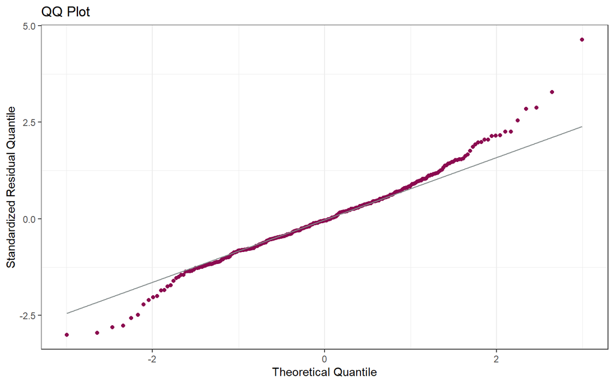

```r
ggplot(y , aes(sample = rstandard(y))) +
  geom_qq(color = 'deeppink4') +
  stat_qq_line(color = 'azure4') +
  labs(title = "QQ Plot", x = "Theoretical Quantile", y = "Standardized Residual Quantile") +
  theme_bw() +
  theme(panel.grid.major.y = element_blank(),
        legend.position = "off")
```

The QQ plot shows heavy tail at the both ends, indicating that our normality assumption is quiet dubious. We can further apply some transformation to remedify the problem.

# Reference

Imbens, G., & Rubin, D. (2015). Stratified Randomized Experiments. In Causal Inference for Statistics, Social, and Biomedical Sciences: An Introduction (pp. 187-218). Cambridge: Cambridge University Press. doi:10.1017/CBO9781139025751.010